# MS report for case study

Naila Bouterfa

27/01/2021

# Loading of the file and libraries

The libraries :

```r
rm(list=ls())
#install.packages("openxlsx")
#install.packages("xlsx")
#install.packages("stringr")
#install.packages("tidyverse")
#install.packages("ggplot2")
#install.packages("tidyr")
#install.packages("dplyr")
#install.packages("kableExtra")

library(openxlsx)
library(xlsx)
library(stringr)
library(tidyverse)
library(tidyr)
library(dplyr)
library(ggplot2)
library(kableExtra)
```

File loading :

```r
MS_Quest=read.xlsx2("C:/Users/Naila/Desktop/etudedecascarenity/Carenity - Case study - Data - MS out of pocket.xlsx", sheetIndex=1,check.names=FALSE)

kable(head(MS_Quest)) %>%
  kable_styling(font_size = 9)%>%
  kableExtra::scroll_box(width = "100%", height = "300px")
```

User

1. You are:
2. Your birth date:
3. The highest diploma obtained:
4. Your profile:
5. What is your professional situation?
6. Have you had to take time off work because of your MS within the last 12 months? Yes, I have taken paid leave

Yes, I’ve taken unpaid leave

Yes, I’ve taken sick leave

No

6bis. How many days did you have to take?

7. What type of MS were you diagnosed with by your neurologist?
8. How old were you when you experienced MS symptoms for the first time?
9. In what year were you diagnosed with MS by a medical professional?
10. Which medical professionals have you seen for your MS within the last 12 months? GP

Neurologist

Ophtalmologist

Psychiatrist

11. How many times have you seen your GP within the last 12 months?
12. When you have an appointment with your GP, does part of the fee have to be paid out of pocket? If yes, what is the amount of your out-of-pocket expense?
11. How many times have you seen your neurologist within the last 12 months?
12. When you have an appointment with your neurologist, does part of the fee have to be paid out of pocket? If yes, what is the amount of your out-of-pocket expense?
11. How many times have you seen your ophtalmologist within the last 12 months?
12. When you have an appointment with your ophtalmologist, does part of the fee have to be paid out of pocket? If yes, what is the amount of your out-of-pocket expense?
11. How many times have you seen your psychiatrist within the last 12 months?
12. When you have an appointment with your psychiatrist, does part of the fee have to be paid out of pocket? If yes, what is the amount of your out-of-pocket expense?
13. In your opinion, which expense items should be better reimbursed? Hospital fees

Medical appointments

Medical exams

Spesialized hospital care

Treatments

Home care services

Home adjustments

Medical material

Medical transport

No item should be better reimbursed

6

Woman

28694

Bachelor’s degree (or the equivalent of 3-4 years of college)

I am affected by multiple sclerosis (MS)

I work full time (employee, self-employed)

X

80

RRMS: relapsing-remitting MS. This type is characterised by attacks with periods of remission (periods stability). After each attack, the symptoms can disappear completely or partially.

29

2011

X

3

Everything is taken care of by social security or by my insurance

X

7

Woman

35388

High school diploma, technical certificate, BEA, BEC, BEI, BEH or equivalent

I am affected by multiple sclerosis (MS)

I don’t work for reasons other than my MS (student, retired, seeking employment, homemaker, unemployed)

0

RRMS: relapsing-remitting MS. This type is characterised by attacks with periods of remission (periods stability). After each attack, the symptoms can disappear completely or partially.

14

2014

X

3

Everything is taken care of by social security or by my insurance

X

X

X

8

Woman

13663

High school diploma, technical certificate, BEA, BEC, BEI, BEH or equivalent

I am affected by multiple sclerosis (MS)

I don’t work for reasons other than my MS (student, retired, seeking employment, homemaker, unemployed)

0

PPMS: primary progressive MS. The condition progresses gradually, smoothly and without exacerbations.

51

1988

X

2

Everything is taken care of by social security or by my insurance

X

X

9

Man

31451

Certificate of professional aptitude (CAP), Certificate of professional studies (BEP), middle school certificate (DNB), certificate of the first cycle of the second degree studies (BEPC)

I am affected by multiple sclerosis (MS)

I work full time (employee, self-employed)

X

15

RRMS: relapsing-remitting MS. This type is characterised by attacks with periods of remission (periods stability). After each attack, the symptoms can disappear completely or partially.

29

2015

X

X

3

Everything is taken care of by social security or by my insurance

3

Everything is taken care of by social security or by my insurance

X

X

X

10

Woman

27773

BTS, DUT, DEUG, DEUST, social studies diploma, 2-years medical diploma, or equivalent

I am affected by multiple sclerosis (MS)

I work full time (employee, self-employed)

X

0

RRMS: relapsing-remitting MS. This type is characterised by attacks with periods of remission (periods stability). After each attack, the symptoms can disappear completely or partially.

27

2011

X

X

X

1

I have to pay between 20 and 30 euros

3

Everything is taken care of by social security or by my insurance

1

I have to pay more than 30 euros

X

X

X

11

Woman

19233

Bachelor’s degree (or the equivalent of 3-4 years of college)

I am affected by multiple sclerosis (MS)

I don’t work for reasons other than my MS (student, retired, seeking employment, homemaker, unemployed)

0

PPMS: primary progressive MS. The condition progresses gradually, smoothly and without exacerbations.

23

1975

X

1

I have to pay more than 30 euros

X

X

X

# Data preprocessing

Let’s start by modifying the column names, to make the variable easier to manipulate and more adapted for a use in R :

```r
# We rename the columns
new_col=c("user","sex","birth_date","diploma","MS_status","work","leave_1","leave_2","leave_3","leave_4", "n_days", "type_MS","age_sympt","MS_diag","med_1","med_2","med_3","med_4","n_GP","fee_GP","n_neuro","fee_neuro","n_ophta","fee_ophta","n_psy","fee_psy","reimb_1","reimb_2","reimb_3","reimb_4","reimb_5","reimb_6","reimb_7","reimb_8","reimb_9","reimb_10")

# We create a new data frame (a copy with the new column names)
MS_QuestData=MS_Quest
colnames(MS_QuestData)=new_col
```

We can store the corresponding variable names in a table as below :

```r
old_col=as.vector(colnames(MS_Quest))
specifications=cbind(old_col,new_col)
kable(specifications)%>%kable_paper("hover", full_width = F,position = "left") %>%
  kable_styling(font_size = 9)%>%
  kableExtra::scroll_box(width = "100%", height = "300px")
```

old_col

new_col

User

user

1. You are:

sex

2. Your birth date:

birth_date

3. The highest diploma obtained:

diploma

4. Your profile:

MS_status

5. What is your professional situation?

work

6. Have you had to take time off work because of your MS within the last 12 months? Yes, I have taken paid leave

leave_1

Yes, I’ve taken unpaid leave

leave_2

Yes, I’ve taken sick leave

leave_3

No

leave_4

6bis. How many days did you have to take?

n_days

7. What type of MS were you diagnosed with by your neurologist?

type_MS

8. How old were you when you experienced MS symptoms for the first time?

age_sympt

9. In what year were you diagnosed with MS by a medical professional?

MS_diag

10. Which medical professionals have you seen for your MS within the last 12 months? GP

med_1

Neurologist

med_2

Ophtalmologist

med_3

Psychiatrist

med_4

11. How many times have you seen your GP within the last 12 months?

n_GP

12. When you have an appointment with your GP, does part of the fee have to be paid out of pocket? If yes, what is the amount of your out-of-pocket expense?

fee_GP

11. How many times have you seen your neurologist within the last 12 months?

n_neuro

12. When you have an appointment with your neurologist, does part of the fee have to be paid out of pocket? If yes, what is the amount of your out-of-pocket expense?

fee_neuro

11. How many times have you seen your ophtalmologist within the last 12 months?

n_ophta

12. When you have an appointment with your ophtalmologist, does part of the fee have to be paid out of pocket? If yes, what is the amount of your out-of-pocket expense?

fee_ophta

11. How many times have you seen your psychiatrist within the last 12 months?

n_psy

12. When you have an appointment with your psychiatrist, does part of the fee have to be paid out of pocket? If yes, what is the amount of your out-of-pocket expense?

fee_psy

13. In your opinion, which expense items should be better reimbursed? Hospital fees

reimb_1

Medical appointments

reimb_2

Medical exams

reimb_3

Spesialized hospital care

reimb_4

Treatments

reimb_5

Home care services

reimb_6

Home adjustments

reimb_7

Medical material

reimb_8

Medical transport

reimb_9

No item should be better reimbursed

reimb_10

We notice that the date format for the birth_date variable isn’t right

Fixing the date format :

```r
#class(MS_QuestData$birth_date)

# In order to apply convertTODate function we need to convert the variable to a character format first
MS_QuestData$birth_date=as.character.factor(MS_QuestData$birth_date)
# Conversion to a Date type variable
new_date=convertToDate(MS_QuestData$birth_date, origin = "1900-01-01")
# Let's change the date's format
new_date=format(new_date,format="%d/%m/%Y")
# Now we add the non numeric values /non-converted ones
new_date[which(is.na(new_date)==TRUE)]=format(MS_QuestData$birth_date[which(is.na(new_date)==TRUE)],format="%d/%m/%Y")

#class(new_date)
new_date=as.Date(new_date,format="%d/%m/%Y" ,origin = "1900-01-01")

#We replace the original variable with the new date variable
MS_QuestData$birth_date=new_date
```

Let’s add a new informative variable the age of diagnosis, which is easier to read then year of diagnosis

```r
MS_QuestData$MS_diag=as.Date(MS_QuestData$MS_diag,format="%Y")

no_na=which(is.na(MS_QuestData$MS_diag)==F)

#which(is.na(MS_QuestData$birth_date)==F)

source("https://raw.githubusercontent.com/jknowles/eeptools/master/R/age_calc.R")

age_diag=rep(NA,dim(MS_QuestData)[1])
age_diag[no_na]=age_calc(MS_QuestData$birth_date[no_na], MS_QuestData$MS_diag[no_na], units = "years", precise = FALSE)
```

We can now reorganise our variables and add the new one :

```r
MS_QuestData=cbind(MS_QuestData,age_diag)
MS_QuestData=MS_QuestData[,c("user","sex","birth_date","diploma","work","MS_status","type_MS","age_sympt","MS_diag","age_diag","leave_1","leave_2","leave_3","leave_4","n_days","med_1","med_2","med_3","med_4","n_GP","fee_GP","n_neuro","fee_neuro","n_ophta","fee_ophta","n_psy","fee_psy","reimb_1","reimb_2","reimb_3","reimb_4","reimb_5","reimb_6","reimb_7","reimb_8","reimb_9","reimb_10" )]
```

As a result we obtain the following dataframe :

```r
kable(head(MS_QuestData)) %>%
  kable_styling(font_size = 9)%>%
  kableExtra::scroll_box(width = "100%", height = "300px")
```

| user | sex | birth_date | diploma | work | MS_status | type_MS | age_sympt | MS_diag | age_diag | leave_1 | leave_2 | leave_3 | leave_4 | n_days | med_1 | med_2 | med_3 | med_4 | n_GP | fee_GP | n_neuro | fee_neuro | n_ophta | fee_ophta | n_psy | fee_psy | reimb_1 | reimb_2 | reimb_3 | … |
| --- | --- | --- | --- | --- | --- | --- | --- | --- | --- | --- | --- | --- | --- | --- | --- | --- | --- | --- | --- | --- | --- | --- | --- | --- | --- | --- | --- | --- | --- | --- |
| 6 | Woman | 1978-07-23 | Bachelor’s degree (or the equivalent of 3-4 years of college) | I work full time (employee, self-employed) | I am affected by multiple sclerosis (MS) | RRMS: relapsing-remitting MS. This type is characterised by attacks with periods of remission (periods stability). After each attack, the symptoms can disappear completely or partially. | 29 | 2011-01-28 | 32 |  |  | X |  | 80 |  | X |  |  |  |  | 3 | Everything is taken care of by social security or by my insurance |  |  |  |  |  |  |  | … |
| 7 | Woman | 1996-11-19 | High school diploma, technical certificate, BEA, BEC, BEI, BEH or equivalent | I don’t work for reasons other than my MS (student, retired, seeking employment, homemaker, unemployed) | I am affected by multiple sclerosis (MS) | RRMS: relapsing-remitting MS. This type is characterised by attacks with periods of remission (periods stability). After each attack, the symptoms can disappear completely or partially. | 14 | 2014-01-28 | 17 |  |  |  |  | 0 |  | X |  |  |  |  | 3 | Everything is taken care of by social security or by my insurance |  |  |  |  | X |  |  | … |
| 8 | Woman | 1937-05-28 | High school diploma, technical certificate, BEA, BEC, BEI, BEH or equivalent | I don’t work for reasons other than my MS (student, retired, seeking employment, homemaker, unemployed) | I am affected by multiple sclerosis (MS) | PPMS: primary progressive MS. The condition progresses gradually, smoothly and without exacerbations. | 51 | 1988-01-28 | 50 |  |  |  |  | 0 |  | X |  |  |  |  | 2 | Everything is taken care of by social security or by my insurance |  |  |  |  |  |  |  | … |
| 9 | Man | 1986-02-08 | Certificate of professional aptitude (CAP), Certificate of professional studies (BEP), middle school certificate (DNB), certificate of the first cycle of the second degree studies (BEPC) | I work full time (employee, self-employed) | I am affected by multiple sclerosis (MS) | RRMS: relapsing-remitting MS. This type is characterised by attacks with periods of remission (periods stability). After each attack, the symptoms can disappear completely or partially. | 29 | 2015-01-28 | 28 |  |  | X |  | 15 | X | X |  |  | 3 | Everything is taken care of by social security or by my insurance | 3 | Everything is taken care of by social security or by my insurance |  |  |  |  |  |  |  | … |
| 10 | Woman | 1976-01-14 | BTS, DUT, DEUG, DEUST, social studies diploma, 2-years medical diploma, or equivalent | I work full time (employee, self-employed) | I am affected by multiple sclerosis (MS) | RRMS: relapsing-remitting MS. This type is characterised by attacks with periods of remission (periods stability). After each attack, the symptoms can disappear completely or partially. | 27 | 2011-01-28 | 35 |  |  |  | X | 0 | X | X | X |  | 1 | I have to pay between 20 and 30 euros | 3 | Everything is taken care of by social security or by my insurance | 1 | I have to pay more than 30 euros |  |  | X |  | X | … |
| 11 | Woman | 1952-08-27 | Bachelor’s degree (or the equivalent of 3-4 years of college) | I don’t work for reasons other than my MS (student, retired, seeking employment, homemaker, unemployed) | I am affected by multiple sclerosis (MS) | PPMS: primary progressive MS. The condition progresses gradually, smoothly and without exacerbations. | 23 | 1975-01-28 | 22 |  |  |  |  | 0 |  | X |  |  |  |  | 1 | I have to pay more than 30 euros |  |  |  |  |  |  |  | … |

We can as well convert empty fields into NA and convert dates to the right format

```r
MS_QuestData$birth_date=format(MS_QuestData$birth_date,format="%d/%m/%Y")
MS_QuestData$MS_diag=format(MS_QuestData$MS_diag,format="%Y")

MS_QuestData[MS_QuestData==""]<-NA

kable(head(MS_QuestData)) %>%
  kable_styling(font_size = 9)%>%
  kableExtra::scroll_box(width = "100%", height = "300px")
```

| user | sex | birth_date | diploma | work | MS_status | type_MS | age_sympt | MS_diag | age_diag | leave_1 | leave_2 | leave_3 | leave_4 | n_days | med_1 | med_2 | med_3 | med_4 | n_GP | fee_GP | n_neuro | fee_neuro | n_ophta | fee_ophta | n_psy | fee_psy | reimb_1 | reimb_2 | reimb_3 | … |
| --- | --- | --- | --- | --- | --- | --- | --- | --- | --- | --- | --- | --- | --- | --- | --- | --- | --- | --- | --- | --- | --- | --- | --- | --- | --- | --- | --- | --- | --- | --- |
| 6 | Woman | 23/07/1978 | Bachelor’s degree (or the equivalent of 3-4 years of college) | I work full time (employee, self-employed) | I am affected by multiple sclerosis (MS) | RRMS: relapsing-remitting MS. This type is characterised by attacks with periods of remission (periods stability). After each attack, the symptoms can disappear completely or partially. | 29 | 2011 | 32 | NA | NA | X | NA | 80 | NA | X | NA | NA | NA | NA | 3 | Everything is taken care of by social security or by my insurance | NA | NA | NA | NA | NA | NA | NA | … |
| 7 | Woman | 19/11/1996 | High school diploma, technical certificate, BEA, BEC, BEI, BEH or equivalent | I don’t work for reasons other than my MS (student, retired, seeking employment, homemaker, unemployed) | I am affected by multiple sclerosis (MS) | RRMS: relapsing-remitting MS. This type is characterised by attacks with periods of remission (periods stability). After each attack, the symptoms can disappear completely or partially. | 14 | 2014 | 17 | NA | NA | NA | NA | 0 | NA | X | NA | NA | NA | NA | 3 | Everything is taken care of by social security or by my insurance | NA | NA | NA | NA | X | NA | NA | … |
| 8 | Woman | 28/05/1937 | High school diploma, technical certificate, BEA, BEC, BEI, BEH or equivalent | I don’t work for reasons other than my MS (student, retired, seeking employment, homemaker, unemployed) | I am affected by multiple sclerosis (MS) | PPMS: primary progressive MS. The condition progresses gradually, smoothly and without exacerbations. | 51 | 1988 | 50 | NA | NA | NA | NA | 0 | NA | X | NA | NA | NA | NA | 2 | Everything is taken care of by social security or by my insurance | NA | NA | NA | NA | NA | NA | NA | … |
| 9 | Man | 08/02/1986 | Certificate of professional aptitude (CAP), Certificate of professional studies (BEP), middle school certificate (DNB), certificate of the first cycle of the second degree studies (BEPC) | I work full time (employee, self-employed) | I am affected by multiple sclerosis (MS) | RRMS: relapsing-remitting MS. This type is characterised by attacks with periods of remission (periods stability). After each attack, the symptoms can disappear completely or partially. | 29 | 2015 | 28 | NA | NA | X | NA | 15 | X | X | NA | NA | 3 | Everything is taken care of by social security or by my insurance | 3 | Everything is taken care of by social security or by my insurance | NA | NA | NA | NA | NA | NA | NA | … |
| 10 | Woman | 14/01/1976 | BTS, DUT, DEUG, DEUST, social studies diploma, 2-years medical diploma, or equivalent | I work full time (employee, self-employed) | I am affected by multiple sclerosis (MS) | RRMS: relapsing-remitting MS. This type is characterised by attacks with periods of remission (periods stability). After each attack, the symptoms can disappear completely or partially. | 27 | 2011 | 35 | NA | NA | NA | X | 0 | X | X | X | NA | 1 | I have to pay between 20 and 30 euros | 3 | Everything is taken care of by social security or by my insurance | 1 | I have to pay more than 30 euros | NA | NA | X | NA | X | … |
| 11 | Woman | 27/08/1952 | Bachelor’s degree (or the equivalent of 3-4 years of college) | I don’t work for reasons other than my MS (student, retired, seeking employment, homemaker, unemployed) | I am affected by multiple sclerosis (MS) | PPMS: primary progressive MS. The condition progresses gradually, smoothly and without exacerbations. | 23 | 1975 | 22 | NA | NA | NA | NA | 0 | NA | X | NA | NA | NA | NA | 1 | I have to pay more than 30 euros | NA | NA | NA | NA | NA | NA | NA | … |

**Table with categorical variables :**

Lets create a second table where the variables are converted into numerical categorical variables

```r
MS_QuestData_cat=MS_QuestData

#levels(MS_QuestData_cat$sexe)
levels(MS_QuestData_cat$sex)=c(1,0)
kbl_sex=kable(cbind(label=0:1,signification=levels(MS_QuestData$sexe)),caption = "Sex")%>%
  kable_styling(font_size = 12)

#levels(MS_QuestData_cat$diploma)
levels(MS_QuestData_cat$diploma)=1:6
kbl_dip=kable(cbind(label=1:6,signification=levels(MS_QuestData$diploma)),caption="Diploma")%>% kable_styling(font_size = 12)

#levels(MS_QuestData_cat$MS_status)
levels(MS_QuestData_cat$MS_status)=c(1,0)
kbl_MS_Status=kable(cbind(label=0:1,signification=levels(MS_QuestData$MS_status)),caption="Multiple Sclerosis status")%>%
  kable_styling(font_size = 12)

#levels(MS_QuestData_cat$work)
levels(MS_QuestData_cat$work)=c(NA,1:4)
kbl_work=kable(cbind(label=c(NA,1:4),signification=levels(MS_QuestData$work)),caption="Work situation")%>%
  kable_styling(font_size = 12)


#levels(MS_QuestData_cat$type_MS)
levels(MS_QuestData_cat$type_MS)=c(NA,"unknown","PPMS","RRMS","SPMS")
kbl_MS_type=kable(cbind(label=c(NA,"unknown","PPMS","RRMS","SPMS"),signification=levels(MS_QuestData$type_MS)),caption = "Type of Multiple Sclerosis")%>%
  kable_styling(font_size = 12)

levels(MS_QuestData_cat$fee_GP)=c(NA,1,2,4,5)
levels(MS_QuestData_cat$fee_neuro)=c(NA,1,2,4,5,3,6)
levels(MS_QuestData_cat$fee_ophta)=c(NA,1,4,5,3,6)
levels(MS_QuestData_cat$fee_psy)=c(NA,1,2)

fees=unique(rbind(cbind(label=c(NA,1,2,4,5),signification=levels(MS_QuestData$fee_GP)),cbind(label=c(NA,1,2,4,5,3,6),signification=levels(MS_QuestData$fee_neuro)),cbind(label=c(NA,1,4,5,3,6),signification=levels(MS_QuestData$fee_ophta)),cbind(label=c(NA,1,2),signification=levels(MS_QuestData$fee_psy))))

fees=as.data.frame(fees)
fees=fees[order(fees$label),]
fees=kable(fees,caption = "Fee levels")%>%
  kable_styling(font_size = 12)
```

**Tidying the dataframe :**

Let’s make the data tidy by pivoting the reply columns so that there no longer response variables in the columns

The concerned variables are the work leave variable, the medical professionel variable and the reimbursment preference variable

```r
pivot_leave= MS_QuestData_cat[,c("user","leave_1","leave_2","leave_3","leave_4")] %>% pivot_longer(c(leave_1,leave_2,leave_3,leave_4), names_prefix = "leave_",names_to = "leave", values_to = "value",values_drop_na = TRUE)
pivot_leave=pivot_leave[,1:2]

# Joint
MS_QuestData_tidy=left_join(MS_QuestData_cat,pivot_leave,by="user")[,!names(MS_QuestData_cat)%in%c("leave_1","leave_2","leave_3","leave_4")]
```

```r
pivot_med=MS_QuestData_cat[,c("user","med_1","med_2","med_3","med_4")] %>% pivot_longer(c(med_1,med_2,med_3,med_4), names_prefix = "med_",names_to = "medical_professional", values_to = "value",values_drop_na = TRUE)
pivot_med=pivot_med[,1:2]

# Joint
MS_QuestData_tidy=left_join(MS_QuestData_tidy,pivot_med,by="user")[,!names(MS_QuestData_tidy)%in%c("med_1","med_2","med_3","med_4")]
```

```r
pivot_reimb=MS_QuestData_cat[,c("user","reimb_1","reimb_2","reimb_3","reimb_4","reimb_5","reimb_6","reimb_7","reimb_8","reimb_9","reimb_10")] %>% pivot_longer(c(reimb_1, reimb_2, reimb_3, reimb_4, reimb_5, reimb_6, reimb_7, reimb_8, reimb_9, reimb_10), names_prefix = "reimb_",names_to = "hospital_fee", values_to = "value",values_drop_na = TRUE)
pivot_reimb=pivot_reimb[,1:2]

# Joint
MS_QuestData_tidy=left_join(MS_QuestData_tidy,pivot_reimb,by="user")[,!names(MS_QuestData_tidy)%in%c("reimb_1","reimb_2","reimb_3","reimb_4","reimb_5","reimb_6","reimb_7","reimb_8","reimb_9","reimb_10")]
```

Here is the tidy dataframe :

```r
kable(head(MS_QuestData_tidy))%>%
  kable_styling(font_size = 9)%>%
  kableExtra::scroll_box(width = "100%", height = "300px")
```

| user | sex | birth_date | diploma | work | MS_status | type_MS | age_sympt | MS_diag | age_diag | n_days | n_GP | fee_GP | n_neuro | fee_neuro | n_ophta | fee_ophta | n_psy | fee_psy | leave | medical_professional | hospital_fee |
| --- | --- | --- | --- | --- | --- | --- | --- | --- | --- | --- | --- | --- | --- | --- | --- | --- | --- | --- | --- | --- | --- |
| 6 | 0 | 23/07/1978 | 1 | 3 | 1 | RRMS | 29 | 2011 | 32 | 80 | NA | NA | 3 | 1 | NA | NA | NA | NA | 3 | 2 | 6 |
| 7 | 0 | 19/11/1996 | 6 | 2 | 1 | RRMS | 14 | 2014 | 17 | 0 | NA | NA | 3 | 1 | NA | NA | NA | NA | NA | 2 | 1 |
| 7 | 0 | 19/11/1996 | 6 | 2 | 1 | RRMS | 14 | 2014 | 17 | 0 | NA | NA | 3 | 1 | NA | NA | NA | NA | NA | 2 | 6 |
| 7 | 0 | 19/11/1996 | 6 | 2 | 1 | RRMS | 14 | 2014 | 17 | 0 | NA | NA | 3 | 1 | NA | NA | NA | NA | NA | 2 | 7 |
| 8 | 0 | 28/05/1937 | 6 | 2 | 1 | PPMS | 51 | 1988 | 50 | 0 | NA | NA | 2 | 1 | NA | NA | NA | NA | NA | 2 | 6 |
| 8 | 0 | 28/05/1937 | 6 | 2 | 1 | PPMS | 51 | 1988 | 50 | 0 | NA | NA | 2 | 1 | NA | NA | NA | NA | NA | 2 | 7 |

# Data Visualisation of descriptive variables

## Univariate analysis

### Boxplots

Let’s consider the 2 quantitative variables which are the age of diagnosis and the age of apparition of first symptoms

```r
MS_QuestData$age_sympt=as.numeric(MS_QuestData$age_sympt)

summary(MS_QuestData$age_sympt)
```

```
##    Min. 1st Qu.  Median    Mean 3rd Qu.    Max.    NA's
##    2.00   11.00   15.00   16.52   21.75   33.00       7
```

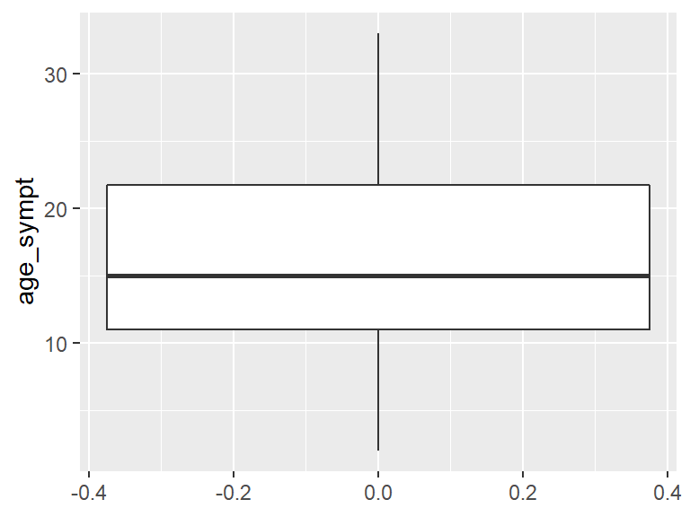

```r
ggplot(MS_QuestData, aes(y = age_sympt)) + geom_boxplot()
```

```r
summary(MS_QuestData$age_diag)
```

```
##    Min. 1st Qu.  Median    Mean 3rd Qu.    Max.    NA's
##   17.00   26.00   36.00   36.36   44.50   60.00       7
```

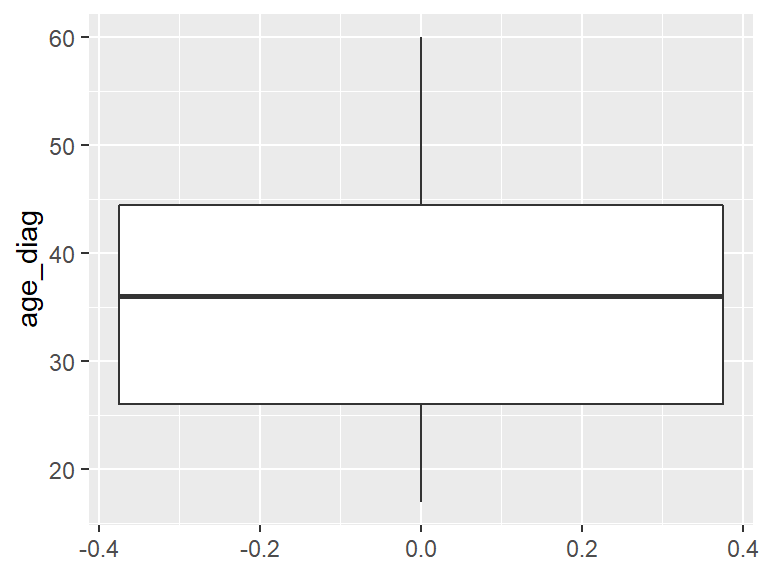

```r
ggplot(MS_QuestData, aes(y = age_diag)) + geom_boxplot()
```

Number of days in a year in which the patient is absent due to MS.

```r
MS_QuestData$n_days=as.numeric(as.character(MS_QuestData$n_days))

summary(MS_QuestData$n_days)
```

```
##    Min. 1st Qu.  Median    Mean 3rd Qu.    Max.
##       0       0       0      11       0     200
```

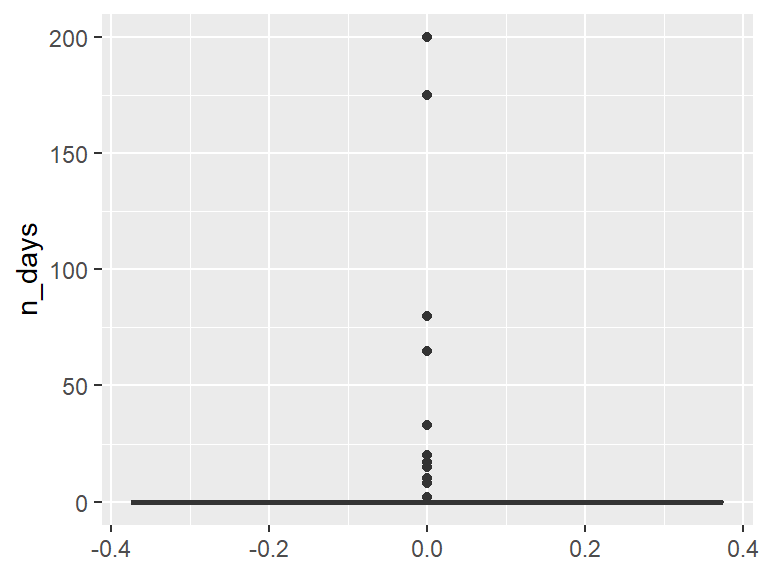

```r
ggplot(MS_QuestData, aes(y = n_days)) + geom_boxplot()
```

Number of visits to different medical professionals :

```r
MS_QuestData$n_GP=as.numeric(as.character(MS_QuestData$n_GP))
MS_QuestData$n_neuro=as.numeric(as.character(MS_QuestData$n_neuro))
MS_QuestData$n_ophta=as.numeric(as.character(MS_QuestData$n_ophta))
MS_QuestData$n_psy=as.numeric(as.character(MS_QuestData$n_psy))
```

```r
summary(MS_QuestData$n_GP)
```

```
##    Min. 1st Qu.  Median    Mean 3rd Qu.    Max.    NA's
##   1.000   4.000   5.500   5.875   6.250  20.000      25
```

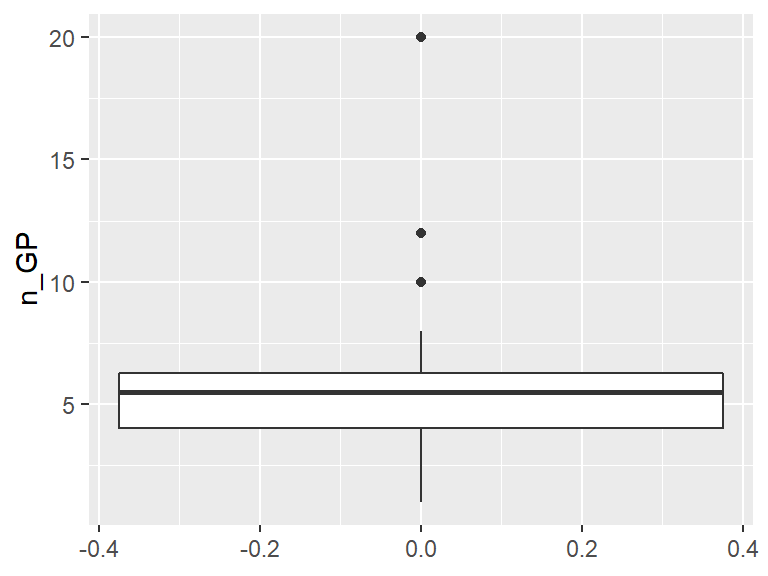

```r
ggplot(MS_QuestData, aes(y = n_GP)) + geom_boxplot()
```

```r
summary(MS_QuestData$n_neuro)
```

```
##    Min. 1st Qu.  Median    Mean 3rd Qu.    Max.    NA's
##   1.000   2.000   2.000   3.196   3.000  15.000      11
```

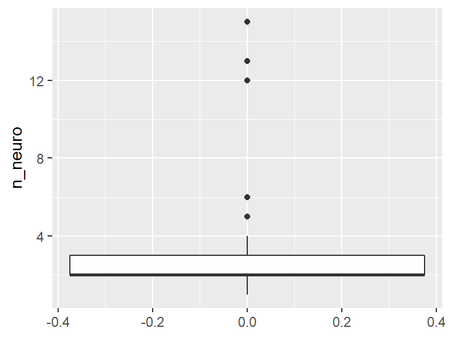

```r
ggplot(MS_QuestData, aes(y = n_neuro)) + geom_boxplot()
```

```r
summary(MS_QuestData$n_ophta)
```

```
##    Min. 1st Qu.  Median    Mean 3rd Qu.    Max.    NA's
##     1.0     1.0     1.0     2.2     3.0     6.0      42
```

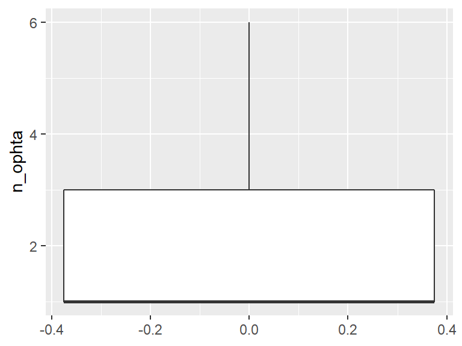

```r
ggplot(MS_QuestData, aes(y = n_ophta)) + geom_boxplot()
```

```r
summary(MS_QuestData$n_psy)
```

```
##    Min. 1st Qu.  Median    Mean 3rd Qu.    Max.    NA's
##    4.00    8.00   12.00   13.67   18.50   25.00      54
```

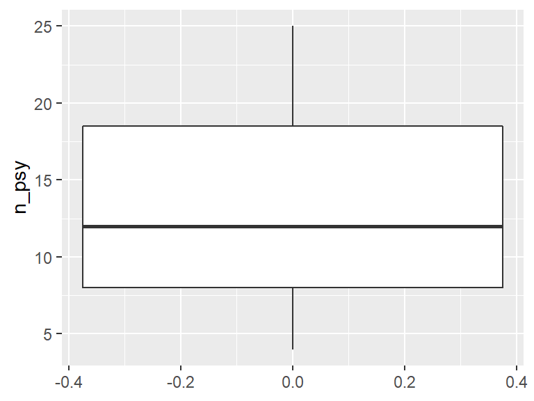

```r
ggplot(MS_QuestData, aes(y = n_psy)) + geom_boxplot()
```

### Histograms and bar charts

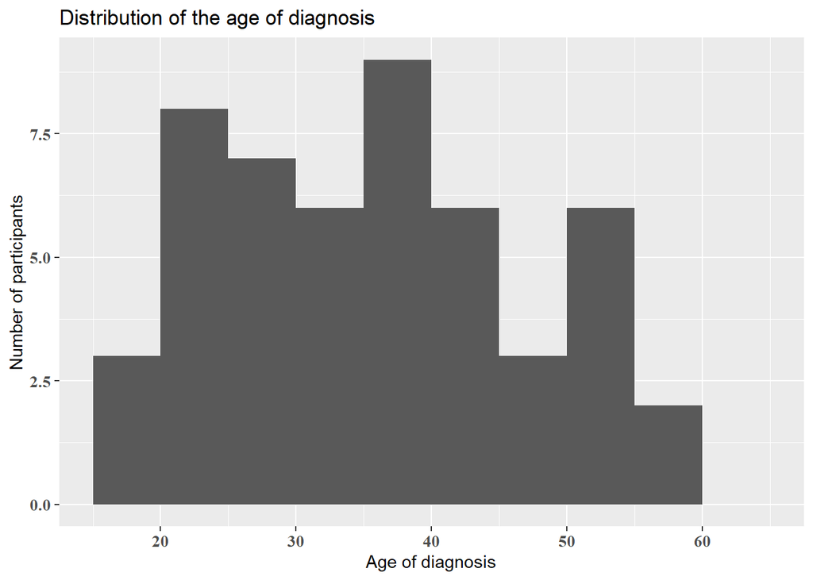

```r
# Age of diagnosis
ggplot(MS_QuestData,aes(age_diag))+
  geom_histogram(breaks = seq(15,65,5))+
  theme(axis.text = element_text(family = "serif", size = 10, face = "bold"))+
  ggtitle("Distribution of the age of diagnosis") +
  xlab("Age of diagnosis") + ylab("Number of participants")
```

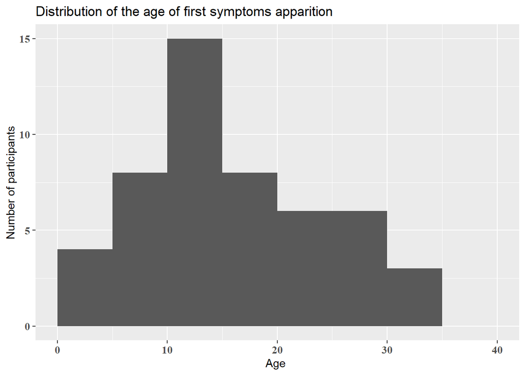

```r
# Age of first symptoms
ggplot(MS_QuestData,aes(age_sympt))+
  geom_histogram(breaks = seq(0,40,5))+
  theme(axis.text = element_text(family = "serif", size = 10, face = "bold"))+
  ggtitle("Distribution of the age of first symptoms apparition") +
  xlab("Age ") + ylab("Number of participants")
```

```r
kbl_sex
```

Sex

| label |
| --- |
| 0 |
| 1 |

```r
table(MS_QuestData$sex)
```

```
##
##   Man Woman
##    13    44
```

```r
# sex

png("sex_repartition.png")
ggplot(MS_QuestData,aes(sex))+
  geom_bar(width = 0.7, position = position_dodge(width = 0.9))+
  theme(axis.text = element_text(family = "serif", size = 10, face = "bold"))+
  ggtitle("Distribution of the sex of participants") +
  xlab("Sex") + ylab("Number of participants")
dev.off()
```

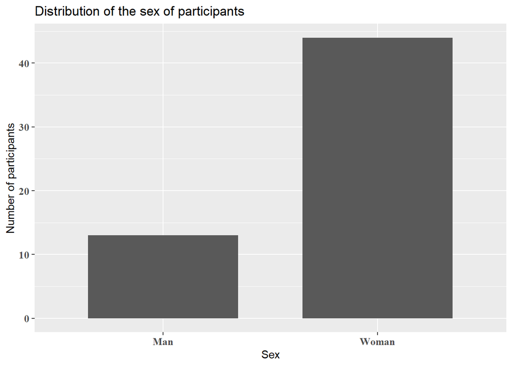

```r
ggplot(MS_QuestData,aes(sex))+
  geom_bar(width = 0.7, position = position_dodge(width = 0.9))+
  theme(axis.text = element_text(family = "serif", size = 10, face = "bold"))+
  ggtitle("Distribution of the sex of participants") +
  xlab("Sex") + ylab("Number of participants")
```

```r
#Diploma

kbl_dip
```

Diploma

| label | signification |
| --- | --- |
| 1 | Bachelor’s degree (or the equivalent of 3-4 years of college) |
| 2 | BTS, DUT, DEUG, DEUST, social studies diploma, 2-years medical diploma, or equivalent |
| 3 | CEP |
| 4 | Certificate of professional aptitude (CAP), Certificate of professional studies (BEP), middle school certificate (DNB), certificate of the first cycle of the second degree studies (BEPC) |
| 5 | Diplomas superiorto a Bachelor’s degree (or equivalent of 4 years of college) |
| 6 | High school diploma, technical certificate, BEA, BEC, BEI, BEH or equivalent |

```r
table(MS_QuestData_cat$diploma)
```

```
##
##  1  2  3  4  5  6
##  9  7  4 13  4 20
```

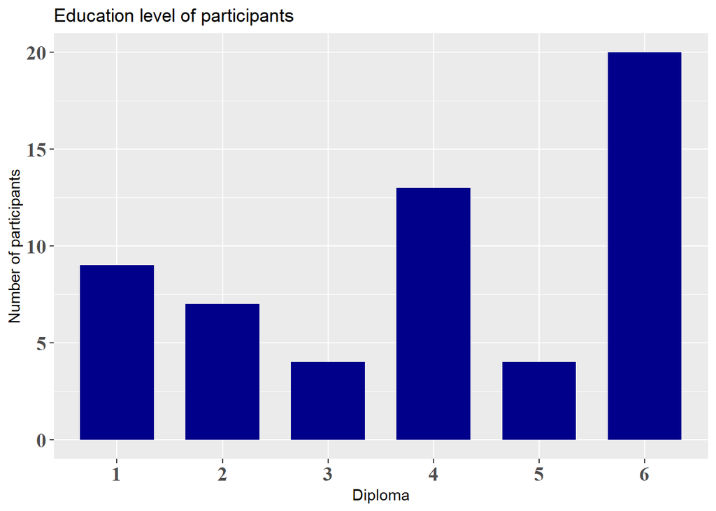

```r
ggplot(MS_QuestData_cat,aes(diploma))+
  geom_bar(width = 0.7, position = position_dodge(width = 0.9),fill="darkblue")+
  theme(axis.text = element_text(family = "serif", size = 14, face = "bold"))+
  ggtitle("Education level of participants") +
  xlab("Diploma") + ylab("Number of participants")
```

```r
#Repartition selon la situation professionnelle

kbl_work
```

Work situation

| label | signification |
| --- | --- |
| NA |  |
| 1 | I don’t work because of my MS (disability pension, prolonged sick leave, early retirement) |
| 2 | I don’t work for reasons other than my MS (student, retired, seeking employment, homemaker, unemployed) |
| 3 | I work full time (employee, self-employed) |
| 4 | I work part-time because of my MS |

```r
table(MS_QuestData_cat$work)
```

```
##
##  1  2  3  4
## 19 13 13  5
```

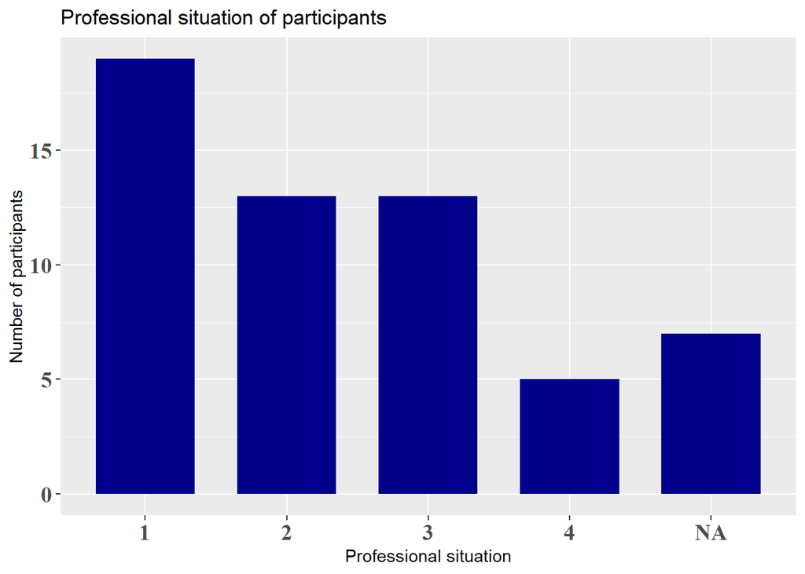

```r
ggplot(MS_QuestData_cat,aes(work))+
  geom_bar(width = 0.7, position = position_dodge(width = 0.9),fill="darkblue")+
  theme(axis.text = element_text(family = "serif", size = 14, face = "bold"))+
  ggtitle("Professional situation of participants") +
  xlab("Professional situation") + ylab("Number of participants")
```

```r
# MS

kbl_MS_Status%>%save_kable("t_ms_status.png")
kbl_MS_Status
```

Multiple Sclerosis status

| label | signification |
| --- | --- |
| 0 | I am affected by multiple sclerosis (MS) |
| 1 | I am not affected by multiple sclerosis (MS) |

```r
table(MS_QuestData_cat$MS_status)
```

```
##
##  1  0
## 50  7
```

```r
png("ms_status.png")
ggplot(MS_QuestData_cat,aes(MS_status))+
  geom_bar(width = 0.7, position = position_dodge(width = 0.9))+
  theme(axis.text = element_text(family = "serif", size = 14, face = "bold",
  vjust = 0.5, hjust=1))+
  ggtitle("") +
  xlab("Multiple Sclerosis status") + ylab("Number of patients")
dev.off()
```

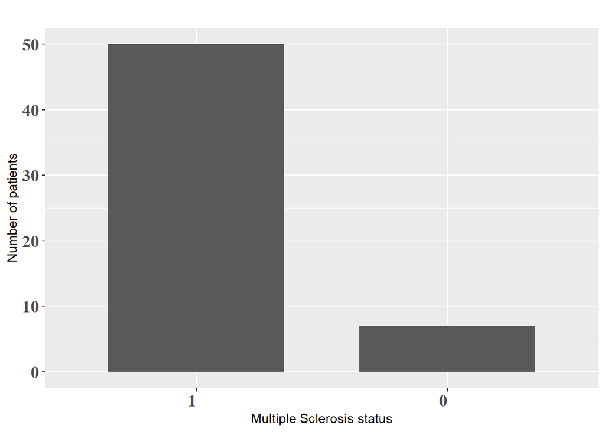

```r
ggplot(MS_QuestData_cat,aes(MS_status))+
  geom_bar(width = 0.7, position = position_dodge(width = 0.9))+
  theme(axis.text = element_text(family = "serif", size = 14, face = "bold",
  vjust = 0.5, hjust=1))+
  ggtitle("") +
  xlab("Multiple Sclerosis status") + ylab("Number of patients")
```

```r
# type of MS

kbl_MS_type%>%save_kable("t_ms_type.png")
kbl_MS_type
```

Type of Multiple Sclerosis

| label | signification |
| --- | --- |
| NA |  |
| unknown | I am not sure/don’t know |
| PPMS | PPMS: primary progressive MS. The condition progresses gradually, smoothly and without exacerbations. |
| RRMS | RRMS: relapsing-remitting MS. This type is characterised by attacks with periods of remission (periods stability). After each attack, the symptoms can disappear completely or partially. |
| SPMS | SPMS: secondary progressive MS. After having progressed for years (or decades)in a remittent mode characterised by attacks, the attacks become less frequent or disappear, but the symptoms continue to … |

```r
table(MS_QuestData_cat$type_MS)
```

```
##
## unknown    PPMS    RRMS    SPMS
##       9      10      24       7
```

```r
png("type_ms.png")
ggplot(MS_QuestData_cat,aes(type_MS))+
  geom_bar(width = 0.7, position = position_dodge(width = 0.9))+
  theme(axis.text = element_text(family = "serif", size = 10, face = "bold",
  vjust = 0.5, hjust=1))+
  ggtitle("Distribution according to the type of Multiple Sclerosis") +
  xlab("Type of Multiple Sclerosis") + ylab("Number of patients")
dev.off()
```

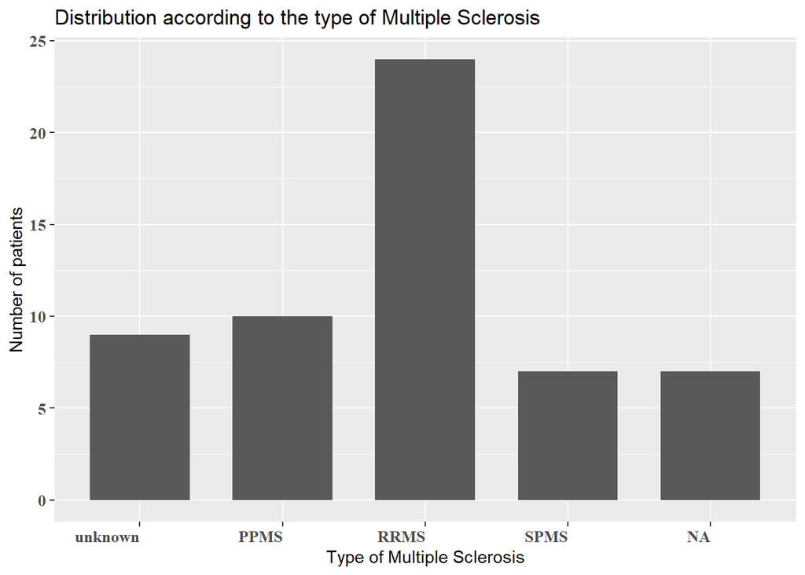

```r
ggplot(MS_QuestData_cat,aes(type_MS))+
  geom_bar(width = 0.7, position = position_dodge(width = 0.9))+
  theme(axis.text = element_text(family = "serif", size = 10, face = "bold",
  vjust = 0.5, hjust=1))+
  ggtitle("Distribution according to the type of Multiple Sclerosis") +
  xlab("Type of Multiple Sclerosis") + ylab("Number of patients")
```

```r
fees%>%save_kable("fees.png")
fees
```

Fee levels

|  | label | signification |
| --- | --- | --- |
| 2 | 1 | Everything is taken care of by social security or by my insurance |
| 3 | 2 | I have to pay between 1 and 5 euros |
| 6 | 3 | I have to pay between 5 and 10 euros |
| 4 | 4 | I have to pay between 10 and 20 euros |
| 5 | 5 | I have to pay between 20 and 30 euros |
| 7 | 6 | I have to pay more than 30 euros |
| 1 | NA |  |

```r
table(MS_QuestData_cat$fee_GP)
```

```
##
##  1  2  4  5
## 19  9  1  3
```

```r
png("fee_GP.png")
ggplot(MS_QuestData_cat,aes(fee_GP))+
  geom_bar(width = 0.7, position = position_dodge(width = 0.9))+
  theme(axis.text = element_text(family = "serif", size = 14, face = "bold",
  vjust = 0.5, hjust=1))+
  ggtitle("Out of pocket expences at the GP") +
  xlab("GP fees") + ylab("Number of participants")
dev.off()
```

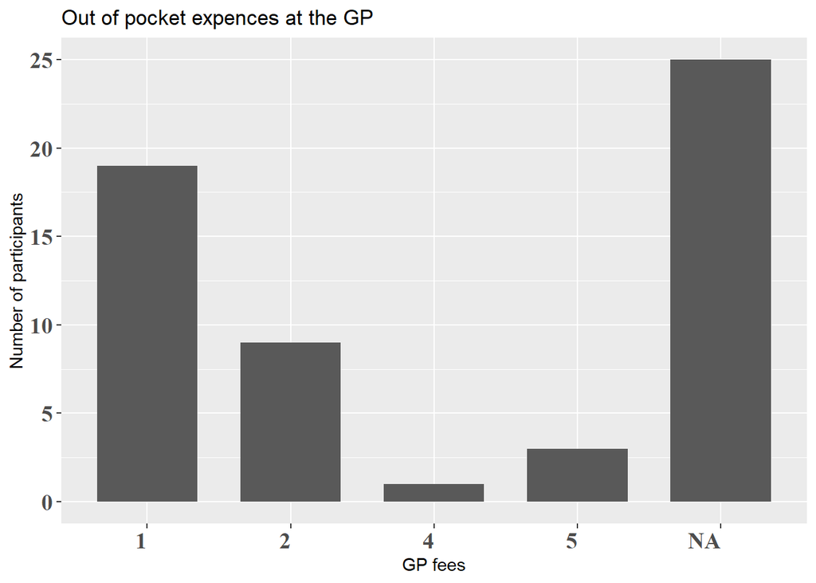

```r
ggplot(MS_QuestData_cat,aes(fee_GP))+
  geom_bar(width = 0.7, position = position_dodge(width = 0.9))+
  theme(axis.text = element_text(family = "serif", size = 14, face = "bold",
  vjust = 0.5, hjust=1))+
  ggtitle("Out of pocket expences at the GP") +
  xlab("GP fees") + ylab("Number of participants")
```

```r
table(MS_QuestData_cat$fee_neuro)
```

```
##
##  1  2  4  5  3  6
## 35  2  3  3  1  2
```

```r
png("fee_neuro.png")
ggplot(MS_QuestData_cat,aes(fee_neuro))+
  geom_bar(width = 0.7, position = position_dodge(width = 0.9))+
  theme(axis.text = element_text(family = "serif", size = 14, face = "bold",
  vjust = 0.5, hjust=1))+
  ggtitle("Out of pocket expences at the neurologist") +
  xlab("Neurologist fees") + ylab("Number of participants")
dev.off()
```

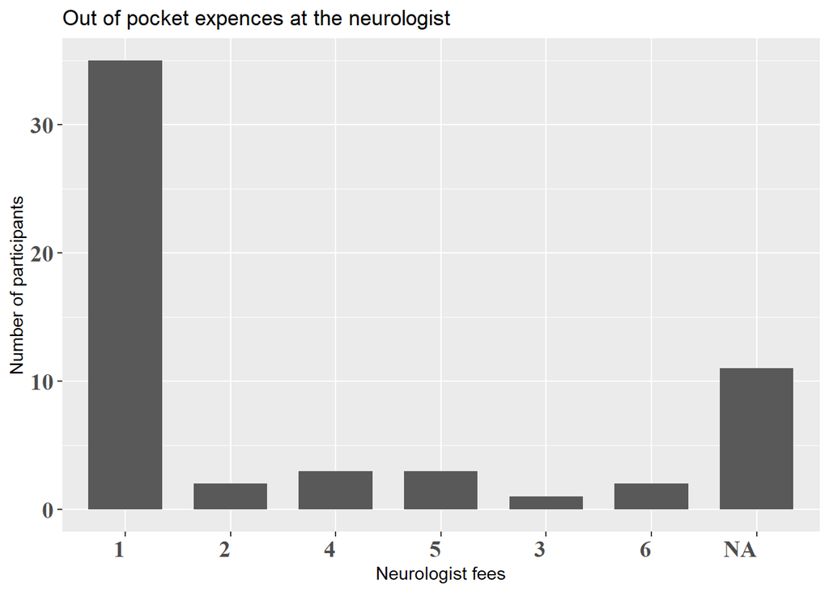

```r
ggplot(MS_QuestData_cat,aes(fee_neuro))+
  geom_bar(width = 0.7, position = position_dodge(width = 0.9))+
  theme(axis.text = element_text(family = "serif", size = 14, face = "bold",
  vjust = 0.5, hjust=1))+
  ggtitle("Out of pocket expences at the neurologist") +
  xlab("Neurologist fees") + ylab("Number of participants")
```

```r
table(MS_QuestData_cat$fee_ophta)
```

```
##
## 1 4 5 3 6
## 6 1 2 1 5
```

```r
png("fee_ophta.png")
ggplot(MS_QuestData_cat,aes(fee_ophta))+
  geom_bar(width = 0.7, position = position_dodge(width = 0.9))+
  theme(axis.text = element_text(family = "serif", size = 14, face = "bold",
  vjust = 0.5, hjust=1))+
  ggtitle("Out of pocket expences at the Ophtalmologist") +
  xlab("Ophtalmologist fees") + ylab("Number of participants")
dev.off()
```

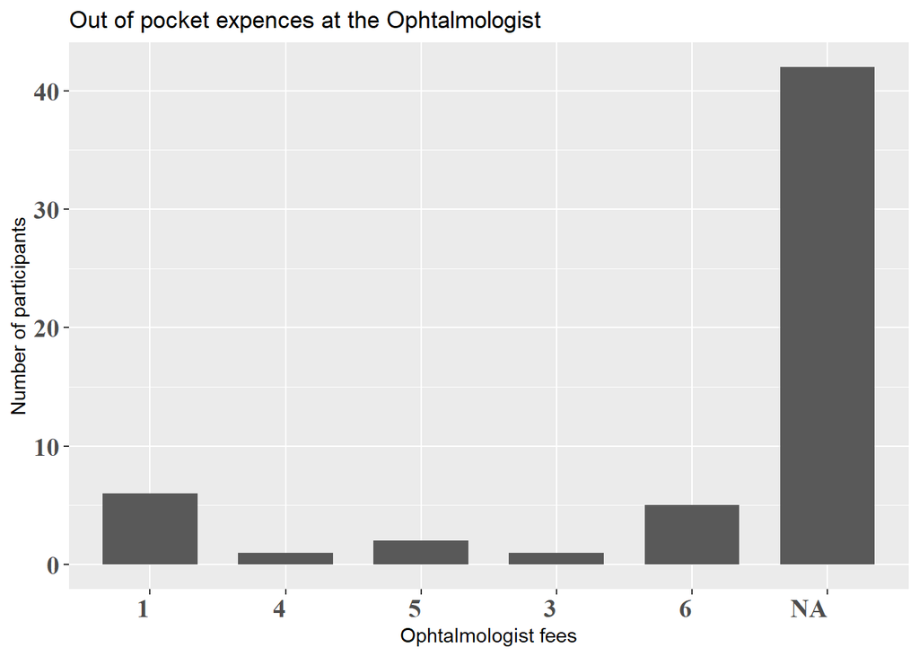

```r
ggplot(MS_QuestData_cat,aes(fee_ophta))+
  geom_bar(width = 0.7, position = position_dodge(width = 0.9))+
  theme(axis.text = element_text(family = "serif", size = 14, face = "bold",
  vjust = 0.5, hjust=1))+
  ggtitle("Out of pocket expences at the Ophtalmologist") +
  xlab("Ophtalmologist fees") + ylab("Number of participants")
```

```r
table(MS_QuestData_cat$fee_psy)
```

```
##
## 1 2
## 2 1
```

```r
png("fee_psy.png")
ggplot(MS_QuestData_cat,aes(fee_psy))+
  geom_bar(width = 0.7, position = position_dodge(width = 0.9))+
  theme(axis.text = element_text(family = "serif", size = 14, face = "bold",
  vjust = 0.5, hjust=1))+
  ggtitle("Out of pocket expences at the psychiatrist") +
  xlab("Psychiatrist fees") + ylab("Number of participants")
dev.off()
```

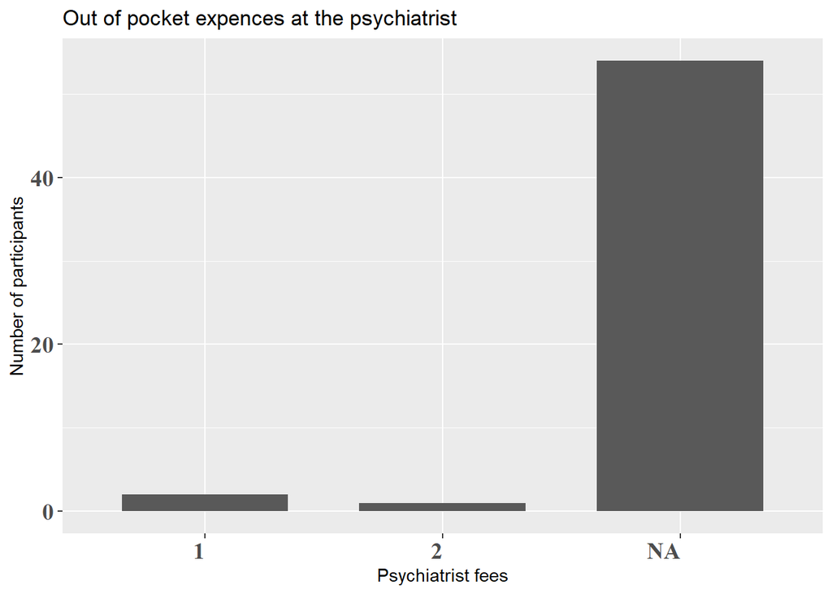

```r
ggplot(MS_QuestData_cat,aes(fee_psy))+
  geom_bar(width = 0.7, position = position_dodge(width = 0.9))+
  theme(axis.text = element_text(family = "serif", size = 14, face = "bold",
  vjust = 0.5, hjust=1))+
  ggtitle("Out of pocket expences at the psychiatrist") +
  xlab("Psychiatrist fees") + ylab("Number of participants")
```

```r
#colnames(MS_Quest)[7:10]

kable(cbind(label=1:4,response=c("Yes, I have taken paid leave", "Yes, I've taken unpaid leave","Yes, I've taken sick leave", "No" )))%>%
  kable_styling(font_size = 12)
```

| label | response |
| --- | --- |
| 1 | Yes, I have taken paid leave |
| 2 | Yes, I’ve taken unpaid leave |
| 3 | Yes, I’ve taken sick leave |
| 4 | No |

```r
table(MS_QuestData_tidy$leave)
```

```
##
##  1  3  4
## 19 35 32
```

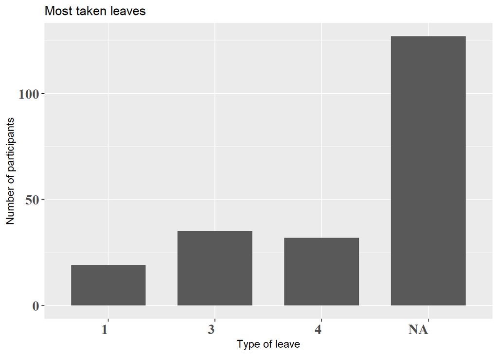

```r
ggplot(MS_QuestData_tidy,aes(leave))+
  geom_bar(width = 0.7, position = position_dodge(width = 0.9))+
  theme(axis.text = element_text(family = "serif", size = 14, face = "bold",
  vjust = 0.5, hjust=1))+
  ggtitle("Most taken leaves") +
  xlab("Type of leave") + ylab("Number of participants")
```

```r
#colnames(MS_Quest)[15:18]
kable(cbind(label=1:4,response=c("GP","Neurologist","Ophtalmologist","Psychiatrist")))%>%
  kable_styling(font_size = 12)%>%save_kable("Med.png")

table(MS_QuestData_tidy$medical_professional)
```

```
##
##  1  2  3  4
## 67 99 36  4
```

```r
png("med_pro.png")
ggplot(MS_QuestData_tidy,aes(medical_professional))+
  geom_bar(width = 0.7, position = position_dodge(width = 0.9))+
  theme(axis.text = element_text(family = "serif", size = 14, face = "bold",
  vjust = 0.5, hjust=1))+
  ggtitle("Most seen medical professional (1 year duration)") +
  xlab("Medical professional") + ylab("Number of participants")
dev.off()
```

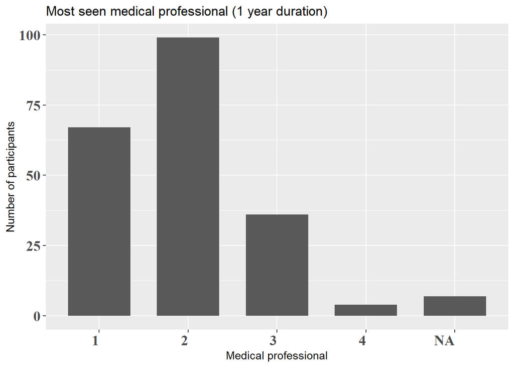

```r
ggplot(MS_QuestData_tidy,aes(medical_professional))+
  geom_bar(width = 0.7, position = position_dodge(width = 0.9))+
  theme(axis.text = element_text(family = "serif", size = 14, face = "bold",
  vjust = 0.5, hjust=1))+
  ggtitle("Most seen medical professional (1 year duration)") +
  xlab("Medical professional") + ylab("Number of participants")
```

```r
#colnames(MS_Quest)[27:36]
kable(cbind(label=1:10,response=c("Hospital fees","Medical appointments","Medical exams","Spesialized hospital care","Treatments", "Home care services", "Home adjustments", "Medical material","Medical transport", "No item should be better reimbursed")))%>%
  kable_styling(font_size = 12) %>% save_kable("Hosp_fees.png")

table(MS_QuestData_tidy$hospital_fee)
```

```
##
##  1 10  2  3  4  5  6  7  8  9
## 18 11 23 23 22 20 34 35  8 10
```

```r
png("reimb.png")
ggplot(MS_QuestData_tidy,aes(hospital_fee))+
  geom_bar(width = 0.7, position = position_dodge(width = 0.9))+
  theme(axis.text = element_text(family = "serif", size = 14, face = "bold",
  vjust = 0.5, hjust=1))+
  ggtitle("Expenses that should be best reimbursed according to participants") +
  xlab("Type of hospital fees") + ylab("Number of participants")
dev.off()
```

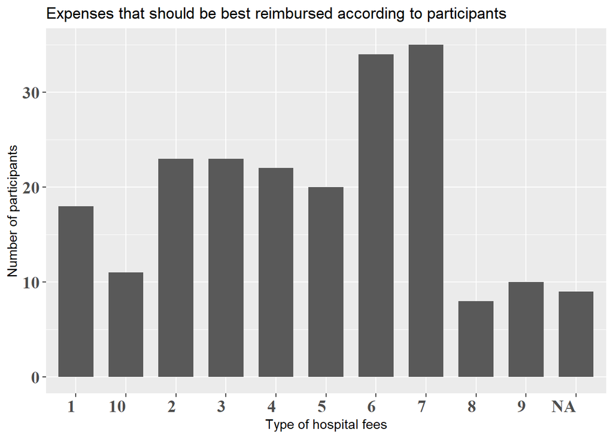

```r
ggplot(MS_QuestData_tidy,aes(hospital_fee))+
  geom_bar(width = 0.7, position = position_dodge(width = 0.9))+
  theme(axis.text = element_text(family = "serif", size = 14, face = "bold",
  vjust = 0.5, hjust=1))+
  ggtitle("Expenses that should be best reimbursed according to participants") +
  xlab("Type of hospital fees") + ylab("Number of participants")
```

## Multivariate analysis

Reimbursment preferences (only patients have responded to the question)

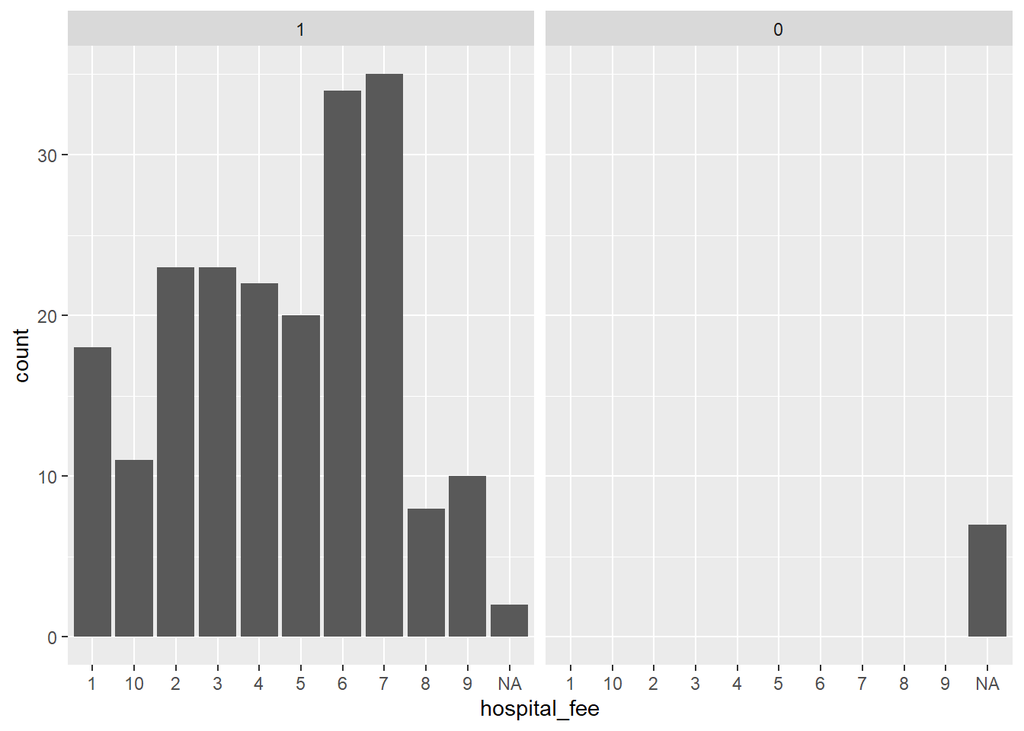

```r
ggplot(data = MS_QuestData_tidy) +
  geom_bar(aes(x = hospital_fee)) +
  facet_wrap(~MS_status)
```

Reimbursment preferences according to the work situation

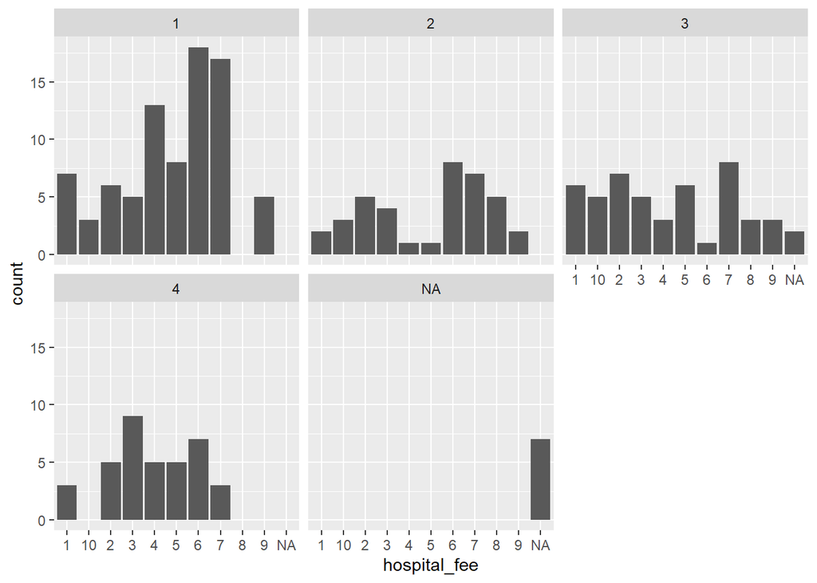

```r
ggplot(data = MS_QuestData_tidy) +
  geom_bar(aes(x = hospital_fee)) +
  facet_wrap(~work)
```

```r
png("hosp_fee_MS_type.png")
ggplot(data = MS_QuestData_tidy) +
  geom_bar(aes(x = hospital_fee)) +
  facet_wrap(~type_MS)+
  ggtitle("Expenses that should be best reimbursed according to patients")+
  xlab("Type of hospital fees") + ylab("Number of participants")
dev.off()
```

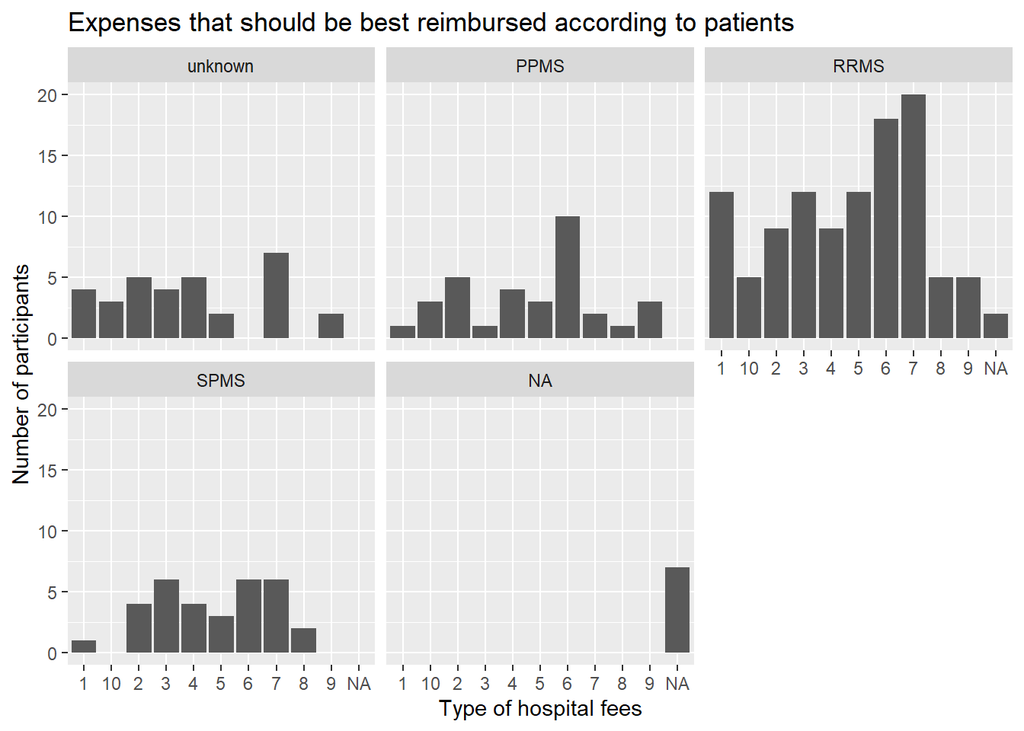

```r
ggplot(data = MS_QuestData_tidy) +
  geom_bar(aes(x = hospital_fee)) +
  facet_wrap(~type_MS)+
  ggtitle("Expenses that should be best reimbursed according to patients")+
  xlab("Type of hospital fees") + ylab("Number of participants")
```

Regarding different medical appointments

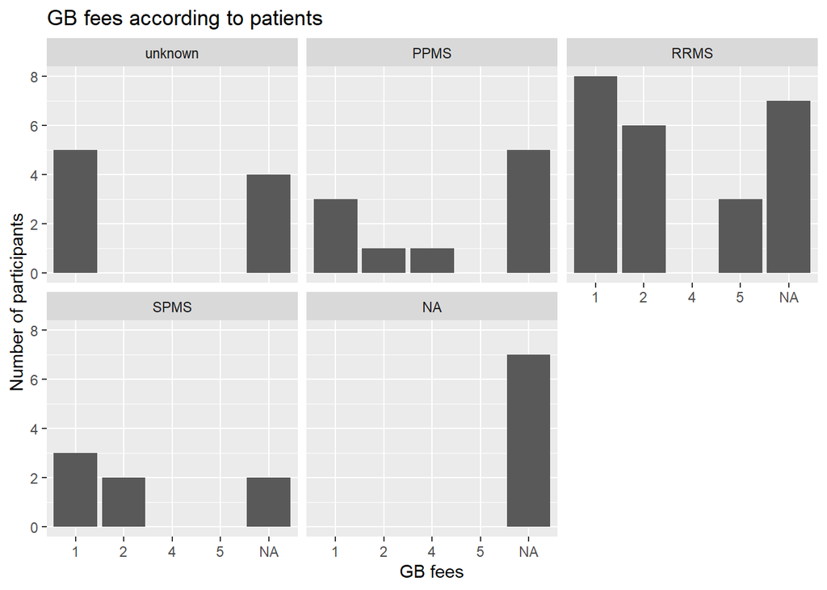

```r
ggplot(data = MS_QuestData_cat) +
  geom_bar(aes(x = fee_GP)) +
  facet_wrap(~type_MS)+
  ggtitle("GB fees according to patients")+
  xlab("GB fees") + ylab("Number of participants")
```

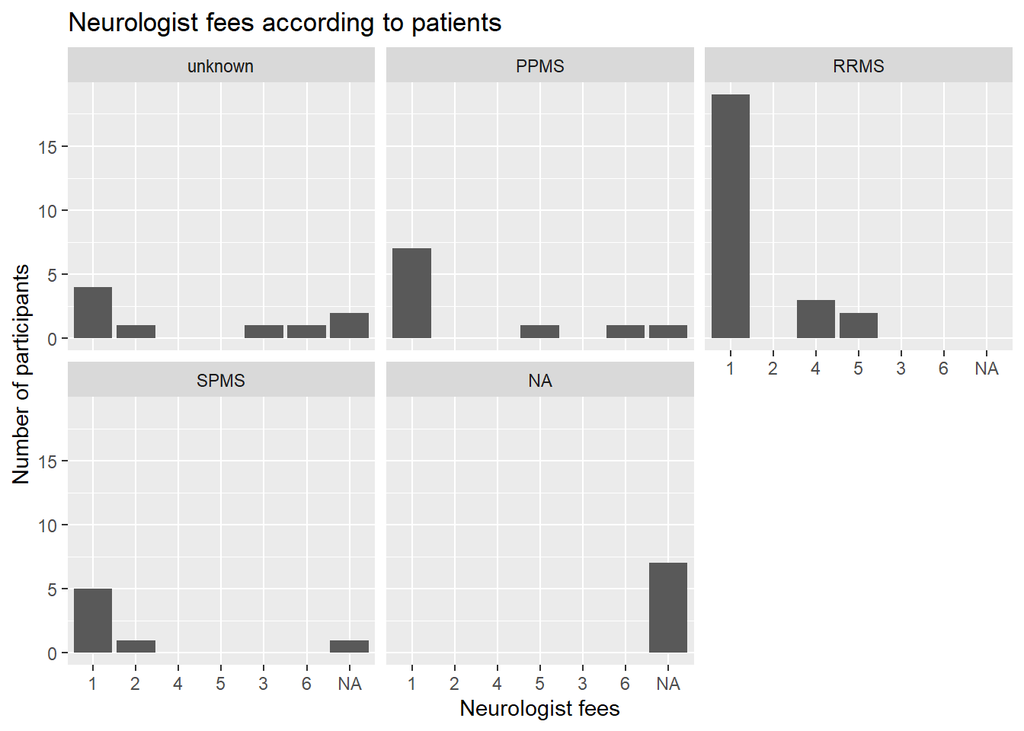

```r
ggplot(data = MS_QuestData_cat) +
  geom_bar(aes(x = fee_neuro)) +
  facet_wrap(~type_MS)+
  ggtitle("Neurologist fees according to patients")+
  xlab("Neurologist fees") + ylab("Number of participants")
```

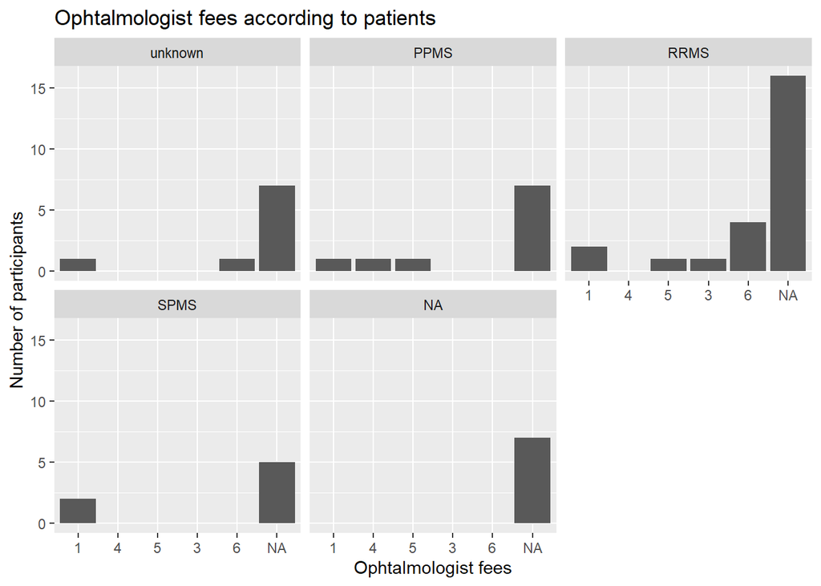

```r
ggplot(data = MS_QuestData_cat) +
  geom_bar(aes(x = fee_ophta)) +
  facet_wrap(~type_MS)+
  ggtitle("Ophtalmologist fees according to patients")+
  xlab("Ophtalmologist fees") + ylab("Number of participants")
```

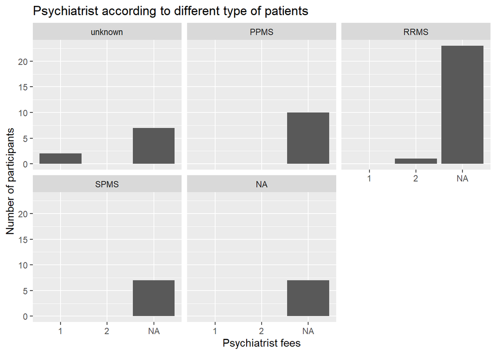

```r
ggplot(data = MS_QuestData_cat) +
  geom_bar(aes(x = fee_psy)) +
  facet_wrap(~type_MS)+
  ggtitle("Psychiatrist according to different type of patients")+
  xlab("Psychiatrist fees") + ylab("Number of participants")
```